# Risk Factor Analysis

## Outcome Variable

**Outcome Variable:** sstunted

## Predictor Variables

**Intervention Variable:** impfloor

**Adjustment Set:**

unadjusted

## Stratifying Variables

The analysis was stratified on these variable(s):

- agecat
- studyid
- country

## Data Summary

| agecat | studyid | country | impfloor | sstunted | n_cell | n |
| --- | --- | --- | --- | --- | --- | --- |
| Birth | ki0047075b-MAL-ED | BANGLADESH | 0 | 0 | 18 | 234 |
| Birth | ki0047075b-MAL-ED | BANGLADESH | 0 | 1 | 0 | 234 |
| Birth | ki0047075b-MAL-ED | BANGLADESH | 1 | 0 | 210 | 234 |
| Birth | ki0047075b-MAL-ED | BANGLADESH | 1 | 1 | 6 | 234 |
| Birth | ki0047075b-MAL-ED | BRAZIL | 0 | 0 | 2 | 174 |
| Birth | ki0047075b-MAL-ED | BRAZIL | 0 | 1 | 0 | 174 |
| Birth | ki0047075b-MAL-ED | BRAZIL | 1 | 0 | 165 | 174 |
| Birth | ki0047075b-MAL-ED | BRAZIL | 1 | 1 | 7 | 174 |
| Birth | ki0047075b-MAL-ED | INDIA | 0 | 0 | 10 | 191 |
| Birth | ki0047075b-MAL-ED | INDIA | 0 | 1 | 0 | 191 |
| Birth | ki0047075b-MAL-ED | INDIA | 1 | 0 | 174 | 191 |
| Birth | ki0047075b-MAL-ED | INDIA | 1 | 1 | 7 | 191 |
| Birth | ki0047075b-MAL-ED | NEPAL | 0 | 0 | 96 | 164 |
| Birth | ki0047075b-MAL-ED | NEPAL | 0 | 1 | 2 | 164 |
| Birth | ki0047075b-MAL-ED | NEPAL | 1 | 0 | 62 | 164 |
| Birth | ki0047075b-MAL-ED | NEPAL | 1 | 1 | 4 | 164 |
| Birth | ki0047075b-MAL-ED | PERU | 0 | 0 | 199 | 259 |
| Birth | ki0047075b-MAL-ED | PERU | 0 | 1 | 4 | 259 |
| Birth | ki0047075b-MAL-ED | PERU | 1 | 0 | 53 | 259 |
| Birth | ki0047075b-MAL-ED | PERU | 1 | 1 | 3 | 259 |
| Birth | ki0047075b-MAL-ED | SOUTH AFRICA | 0 | 0 | 21 | 218 |
| Birth | ki0047075b-MAL-ED | SOUTH AFRICA | 0 | 1 | 0 | 218 |
| Birth | ki0047075b-MAL-ED | SOUTH AFRICA | 1 | 0 | 196 | 218 |
| Birth | ki0047075b-MAL-ED | SOUTH AFRICA | 1 | 1 | 1 | 218 |
| Birth | ki0047075b-MAL-ED | TANZANIA, UNITED REPUBLIC OF | 0 | 0 | 105 | 117 |
| Birth | ki0047075b-MAL-ED | TANZANIA, UNITED REPUBLIC OF | 0 | 1 | 4 | 117 |
| Birth | ki0047075b-MAL-ED | TANZANIA, UNITED REPUBLIC OF | 1 | 0 | 7 | 117 |
| Birth | ki0047075b-MAL-ED | TANZANIA, UNITED REPUBLIC OF | 1 | 1 | 1 | 117 |
| Birth | ki1000108-CMC-V-BCS-2002 | INDIA | 0 | 0 | 0 | 71 |
| Birth | ki1000108-CMC-V-BCS-2002 | INDIA | 0 | 1 | 0 | 71 |

[output cut: 154 more lines]

The following strata were considered:

- agecat: 24 months, studyid: ki0047075b-MAL-ED, country: BANGLADESH
- agecat: 24 months, studyid: ki0047075b-MAL-ED, country: BRAZIL
- agecat: 24 months, studyid: ki0047075b-MAL-ED, country: INDIA
- agecat: 24 months, studyid: ki0047075b-MAL-ED, country: NEPAL
- agecat: 24 months, studyid: ki0047075b-MAL-ED, country: PERU
- agecat: 24 months, studyid: ki0047075b-MAL-ED, country: SOUTH AFRICA
- agecat: 24 months, studyid: ki0047075b-MAL-ED, country: TANZANIA, UNITED REPUBLIC OF
- agecat: 24 months, studyid: ki1000108-CMC-V-BCS-2002, country: INDIA
- agecat: 24 months, studyid: ki1000108-IRC, country: INDIA
- agecat: 24 months, studyid: ki1017093-NIH-Birth, country: BANGLADESH
- agecat: 24 months, studyid: ki1017093b-PROVIDE, country: BANGLADESH
- agecat: 24 months, studyid: ki1017093c-NIH-Crypto, country: BANGLADESH
- agecat: 24 months, studyid: ki1113344-GMS-Nepal, country: NEPAL
- agecat: 24 months, studyid: ki1114097-CONTENT, country: PERU
- agecat: 24 months, studyid: kiGH5241-JiVitA-3, country: BANGLADESH
- agecat: 24 months, studyid: kiGH5241-JiVitA-4, country: BANGLADESH
- agecat: 6 months, studyid: ki0047075b-MAL-ED, country: BANGLADESH
- agecat: 6 months, studyid: ki0047075b-MAL-ED, country: BRAZIL
- agecat: 6 months, studyid: ki0047075b-MAL-ED, country: INDIA
- agecat: 6 months, studyid: ki0047075b-MAL-ED, country: NEPAL
- agecat: 6 months, studyid: ki0047075b-MAL-ED, country: PERU
- agecat: 6 months, studyid: ki0047075b-MAL-ED, country: SOUTH AFRICA
- agecat: 6 months, studyid: ki0047075b-MAL-ED, country: TANZANIA, UNITED REPUBLIC OF
- agecat: 6 months, studyid: ki1000108-CMC-V-BCS-2002, country: INDIA
- agecat: 6 months, studyid: ki1000108-IRC, country: INDIA
- agecat: 6 months, studyid: ki1017093-NIH-Birth, country: BANGLADESH
- agecat: 6 months, studyid: ki1017093b-PROVIDE, country: BANGLADESH
- agecat: 6 months, studyid: ki1017093c-NIH-Crypto, country: BANGLADESH
- agecat: 6 months, studyid: ki1113344-GMS-Nepal, country: NEPAL
- agecat: 6 months, studyid: ki1114097-CONTENT, country: PERU
- agecat: 6 months, studyid: kiGH5241-JiVitA-3, country: BANGLADESH
- agecat: 6 months, studyid: kiGH5241-JiVitA-4, country: BANGLADESH
- agecat: Birth, studyid: ki0047075b-MAL-ED, country: BANGLADESH
- agecat: Birth, studyid: ki0047075b-MAL-ED, country: BRAZIL
- agecat: Birth, studyid: ki0047075b-MAL-ED, country: INDIA
- agecat: Birth, studyid: ki0047075b-MAL-ED, country: NEPAL
- agecat: Birth, studyid: ki0047075b-MAL-ED, country: PERU
- agecat: Birth, studyid: ki0047075b-MAL-ED, country: SOUTH AFRICA
- agecat: Birth, studyid: ki0047075b-MAL-ED, country: TANZANIA, UNITED REPUBLIC OF
- agecat: Birth, studyid: ki1000108-CMC-V-BCS-2002, country: INDIA
- agecat: Birth, studyid: ki1000108-IRC, country: INDIA
- agecat: Birth, studyid: ki1017093-NIH-Birth, country: BANGLADESH
- agecat: Birth, studyid: ki1017093c-NIH-Crypto, country: BANGLADESH
- agecat: Birth, studyid: ki1114097-CONTENT, country: PERU
- agecat: Birth, studyid: kiGH5241-JiVitA-3, country: BANGLADESH
- agecat: Birth, studyid: kiGH5241-JiVitA-4, country: BANGLADESH

### Dropped Strata

Some strata were dropped due to rare outcomes:

- agecat: Birth, studyid: ki0047075b-MAL-ED, country: BANGLADESH
- agecat: Birth, studyid: ki0047075b-MAL-ED, country: BRAZIL
- agecat: Birth, studyid: ki0047075b-MAL-ED, country: INDIA
- agecat: Birth, studyid: ki0047075b-MAL-ED, country: NEPAL
- agecat: Birth, studyid: ki0047075b-MAL-ED, country: PERU
- agecat: Birth, studyid: ki0047075b-MAL-ED, country: SOUTH AFRICA
- agecat: Birth, studyid: ki0047075b-MAL-ED, country: TANZANIA, UNITED REPUBLIC OF
- agecat: Birth, studyid: ki1000108-CMC-V-BCS-2002, country: INDIA
- agecat: Birth, studyid: ki1000108-IRC, country: INDIA
- agecat: Birth, studyid: ki1017093-NIH-Birth, country: BANGLADESH
- agecat: Birth, studyid: ki1017093c-NIH-Crypto, country: BANGLADESH
- agecat: Birth, studyid: ki1114097-CONTENT, country: PERU
- agecat: 6 months, studyid: ki0047075b-MAL-ED, country: BANGLADESH
- agecat: 6 months, studyid: ki0047075b-MAL-ED, country: BRAZIL
- agecat: 6 months, studyid: ki0047075b-MAL-ED, country: INDIA
- agecat: 6 months, studyid: ki0047075b-MAL-ED, country: NEPAL
- agecat: 6 months, studyid: ki0047075b-MAL-ED, country: PERU
- agecat: 6 months, studyid: ki0047075b-MAL-ED, country: SOUTH AFRICA
- agecat: 6 months, studyid: ki0047075b-MAL-ED, country: TANZANIA, UNITED REPUBLIC OF
- agecat: 6 months, studyid: ki1000108-CMC-V-BCS-2002, country: INDIA
- agecat: 6 months, studyid: ki1000108-IRC, country: INDIA
- agecat: 6 months, studyid: ki1017093-NIH-Birth, country: BANGLADESH
- agecat: 6 months, studyid: ki1113344-GMS-Nepal, country: NEPAL
- agecat: 6 months, studyid: ki1114097-CONTENT, country: PERU
- agecat: 24 months, studyid: ki0047075b-MAL-ED, country: BANGLADESH
- agecat: 24 months, studyid: ki0047075b-MAL-ED, country: BRAZIL
- agecat: 24 months, studyid: ki0047075b-MAL-ED, country: INDIA
- agecat: 24 months, studyid: ki0047075b-MAL-ED, country: NEPAL
- agecat: 24 months, studyid: ki0047075b-MAL-ED, country: PERU
- agecat: 24 months, studyid: ki0047075b-MAL-ED, country: SOUTH AFRICA
- agecat: 24 months, studyid: ki0047075b-MAL-ED, country: TANZANIA, UNITED REPUBLIC OF
- agecat: 24 months, studyid: ki1000108-CMC-V-BCS-2002, country: INDIA
- agecat: 24 months, studyid: ki1000108-IRC, country: INDIA
- agecat: 24 months, studyid: ki1113344-GMS-Nepal, country: NEPAL
- agecat: 24 months, studyid: ki1114097-CONTENT, country: PERU

## Methods Detail

We’re interested in the causal parameters $E[Y_a]$ for all values of $a \in \mathcal{A}$. These parameters represent the mean outcome if, possibly contrary to fact, we intervened to set all units to have $A=a$. Under the randomization and positivity assumptions, these are identified by the statistical parameters $\psi_a=E_W[E_{Y|A,W}(Y|A=a,W)]$. In addition, we’re interested in the mean of $Y$, $E[Y]$ under no intervention (the observed mean). We will estimate these parameters by using SuperLearner to fit the relevant likelihood factors – $E_{Y|A,W}(Y|A=a,W)$ and $p(A=a|W)$, and then updating our likelihood fit using a joint TMLE.

For unadjusted analyses ($W=\{\}$), initial likelihoods were estimated using Lrnr_glm to estimate the simple $E(Y|A)$ and Lrnr_mean to estimate $p(A)$. For adjusted analyses, a small library containing Lrnr_glmnet, Lrnr_xgboost, and Lrnr_mean was used.

Having estimated these parameters, we will then use the delta method to estimate relative risks and attributable risks relative to a prespecified baseline level of $A$.

# Results Detail

## Results Plots

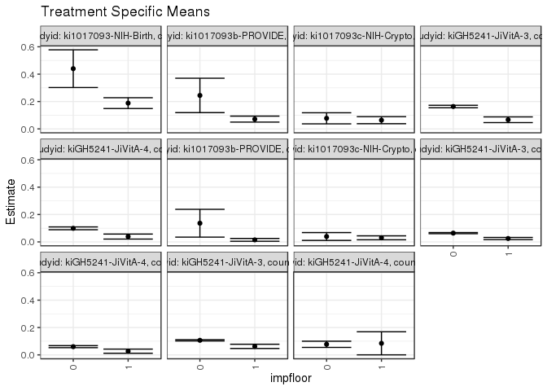

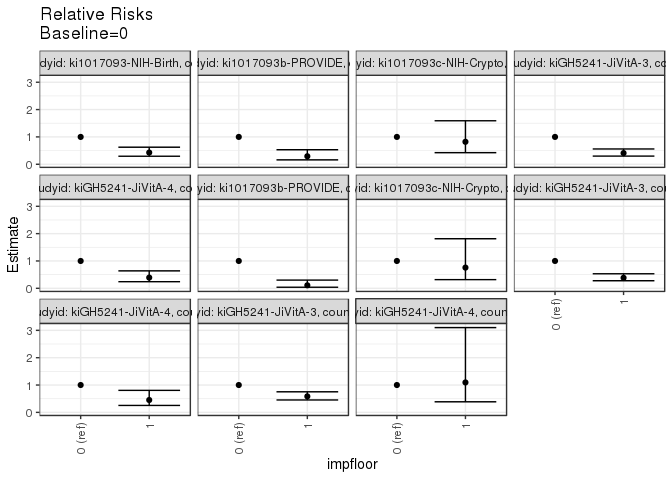

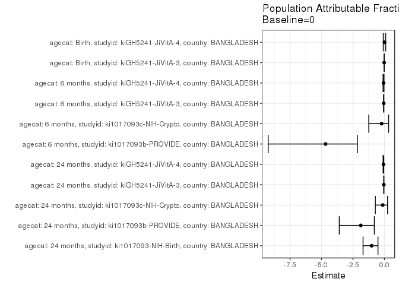

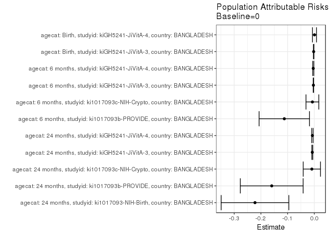

## Results Table

### Parameter: TSM

| agecat | studyid | country | intervention_level | baseline_level | estimate | ci_lower | ci_upper |
| --- | --- | --- | --- | --- | --- | --- | --- |
| Birth | kiGH5241-JiVitA-3 | BANGLADESH | 0 | NA | 0.1065614 | 0.1017202 | 0.1114025 |
| Birth | kiGH5241-JiVitA-3 | BANGLADESH | 1 | NA | 0.0622677 | 0.0468239 | 0.0777114 |
| Birth | kiGH5241-JiVitA-4 | BANGLADESH | 0 | NA | 0.0772304 | 0.0544983 | 0.0999624 |
| Birth | kiGH5241-JiVitA-4 | BANGLADESH | 1 | NA | 0.0845070 | 0.0003034 | 0.1687107 |
| 6 months | ki1017093b-PROVIDE | BANGLADESH | 0 | NA | 0.1363636 | 0.0348769 | 0.2378504 |
| 6 months | ki1017093b-PROVIDE | BANGLADESH | 1 | NA | 0.0148423 | 0.0046251 | 0.0250595 |
| 6 months | ki1017093c-NIH-Crypto | BANGLADESH | 0 | NA | 0.0393258 | 0.0107520 | 0.0678997 |
| 6 months | ki1017093c-NIH-Crypto | BANGLADESH | 1 | NA | 0.0297952 | 0.0154049 | 0.0441854 |
| 6 months | kiGH5241-JiVitA-3 | BANGLADESH | 0 | NA | 0.0640188 | 0.0599190 | 0.0681186 |
| 6 months | kiGH5241-JiVitA-3 | BANGLADESH | 1 | NA | 0.0245734 | 0.0166417 | 0.0325050 |
| 6 months | kiGH5241-JiVitA-4 | BANGLADESH | 0 | NA | 0.0599906 | 0.0525705 | 0.0674106 |
| 6 months | kiGH5241-JiVitA-4 | BANGLADESH | 1 | NA | 0.0271186 | 0.0118993 | 0.0423380 |
| 24 months | ki1017093-NIH-Birth | BANGLADESH | 0 | NA | 0.4400000 | 0.3022497 | 0.5777503 |
| 24 months | ki1017093-NIH-Birth | BANGLADESH | 1 | NA | 0.1883289 | 0.1488164 | 0.2278415 |
| 24 months | ki1017093b-PROVIDE | BANGLADESH | 0 | NA | 0.2444444 | 0.1187715 | 0.3701174 |
| 24 months | ki1017093b-PROVIDE | BANGLADESH | 1 | NA | 0.0714286 | 0.0495251 | 0.0933320 |
| 24 months | ki1017093c-NIH-Crypto | BANGLADESH | 0 | NA | 0.0773810 | 0.0369378 | 0.1178241 |
| 24 months | ki1017093c-NIH-Crypto | BANGLADESH | 1 | NA | 0.0635838 | 0.0378478 | 0.0893198 |
| 24 months | kiGH5241-JiVitA-3 | BANGLADESH | 0 | NA | 0.1634531 | 0.1542849 | 0.1726212 |
| 24 months | kiGH5241-JiVitA-3 | BANGLADESH | 1 | NA | 0.0667656 | 0.0459874 | 0.0875438 |
| 24 months | kiGH5241-JiVitA-4 | BANGLADESH | 0 | NA | 0.0990431 | 0.0887054 | 0.1093808 |
| 24 months | kiGH5241-JiVitA-4 | BANGLADESH | 1 | NA | 0.0388693 | 0.0204899 | 0.0572487 |

### Parameter: E(Y)

| agecat | studyid | country | intervention_level | baseline_level | estimate | ci_lower | ci_upper |
| --- | --- | --- | --- | --- | --- | --- | --- |
| Birth | kiGH5241-JiVitA-3 | BANGLADESH | NA | NA | 0.1041251 | 0.0994430 | 0.1088072 |
| Birth | kiGH5241-JiVitA-4 | BANGLADESH | NA | NA | 0.0778589 | 0.0559066 | 0.0998111 |
| 6 months | ki1017093b-PROVIDE | BANGLADESH | NA | NA | 0.0240137 | 0.0115761 | 0.0364514 |
| 6 months | ki1017093c-NIH-Crypto | BANGLADESH | NA | NA | 0.0321678 | 0.0192256 | 0.0451101 |
| 6 months | kiGH5241-JiVitA-3 | BANGLADESH | NA | NA | 0.0605735 | 0.0567154 | 0.0644317 |
| 6 months | kiGH5241-JiVitA-4 | BANGLADESH | NA | NA | 0.0559701 | 0.0491990 | 0.0627413 |
| 24 months | ki1017093-NIH-Birth | BANGLADESH | NA | NA | 0.2177986 | 0.1786036 | 0.2569935 |
| 24 months | ki1017093b-PROVIDE | BANGLADESH | NA | NA | 0.0849220 | 0.0621566 | 0.1076874 |
| 24 months | ki1017093c-NIH-Crypto | BANGLADESH | NA | NA | 0.0680934 | 0.0462948 | 0.0898920 |
| 24 months | kiGH5241-JiVitA-3 | BANGLADESH | NA | NA | 0.1558834 | 0.1471384 | 0.1646284 |
| 24 months | kiGH5241-JiVitA-4 | BANGLADESH | NA | NA | 0.0918668 | 0.0824774 | 0.1012563 |

### Parameter: RR

| agecat | studyid | country | intervention_level | baseline_level | estimate | ci_lower | ci_upper |
| --- | --- | --- | --- | --- | --- | --- | --- |
| Birth | kiGH5241-JiVitA-3 | BANGLADESH | 0 | 0 | 1.0000000 | 1.0000000 | 1.0000000 |
| Birth | kiGH5241-JiVitA-3 | BANGLADESH | 1 | 0 | 0.5843361 | 0.4540856 | 0.7519479 |
| Birth | kiGH5241-JiVitA-4 | BANGLADESH | 0 | 0 | 1.0000000 | 1.0000000 | 1.0000000 |
| Birth | kiGH5241-JiVitA-4 | BANGLADESH | 1 | 0 | 1.0942205 | 0.3861879 | 3.1003519 |
| 6 months | ki1017093b-PROVIDE | BANGLADESH | 0 | 0 | 1.0000000 | 1.0000000 | 1.0000000 |
| 6 months | ki1017093b-PROVIDE | BANGLADESH | 1 | 0 | 0.1088435 | 0.0394932 | 0.2999735 |
| 6 months | ki1017093c-NIH-Crypto | BANGLADESH | 0 | 0 | 1.0000000 | 1.0000000 | 1.0000000 |
| 6 months | ki1017093c-NIH-Crypto | BANGLADESH | 1 | 0 | 0.7576483 | 0.3166354 | 1.8129082 |
| 6 months | kiGH5241-JiVitA-3 | BANGLADESH | 0 | 0 | 1.0000000 | 1.0000000 | 1.0000000 |
| 6 months | kiGH5241-JiVitA-3 | BANGLADESH | 1 | 0 | 0.3838462 | 0.2769038 | 0.5320906 |
| 6 months | kiGH5241-JiVitA-4 | BANGLADESH | 0 | 0 | 1.0000000 | 1.0000000 | 1.0000000 |
| 6 months | kiGH5241-JiVitA-4 | BANGLADESH | 1 | 0 | 0.4520486 | 0.2540436 | 0.8043813 |
| 24 months | ki1017093-NIH-Birth | BANGLADESH | 0 | 0 | 1.0000000 | 1.0000000 | 1.0000000 |
| 24 months | ki1017093-NIH-Birth | BANGLADESH | 1 | 0 | 0.4280203 | 0.2936242 | 0.6239312 |
| 24 months | ki1017093b-PROVIDE | BANGLADESH | 0 | 0 | 1.0000000 | 1.0000000 | 1.0000000 |
| 24 months | ki1017093b-PROVIDE | BANGLADESH | 1 | 0 | 0.2922078 | 0.1605881 | 0.5317045 |
| 24 months | ki1017093c-NIH-Crypto | BANGLADESH | 0 | 0 | 1.0000000 | 1.0000000 | 1.0000000 |
| 24 months | ki1017093c-NIH-Crypto | BANGLADESH | 1 | 0 | 0.8216985 | 0.4242492 | 1.5914903 |
| 24 months | kiGH5241-JiVitA-3 | BANGLADESH | 0 | 0 | 1.0000000 | 1.0000000 | 1.0000000 |
| 24 months | kiGH5241-JiVitA-3 | BANGLADESH | 1 | 0 | 0.4084694 | 0.2980622 | 0.5597734 |
| 24 months | kiGH5241-JiVitA-4 | BANGLADESH | 0 | 0 | 1.0000000 | 1.0000000 | 1.0000000 |
| 24 months | kiGH5241-JiVitA-4 | BANGLADESH | 1 | 0 | 0.3924481 | 0.2413027 | 0.6382669 |

### Parameter: PAR

| agecat | studyid | country | intervention_level | baseline_level | estimate | ci_lower | ci_upper |
| --- | --- | --- | --- | --- | --- | --- | --- |
| Birth | kiGH5241-JiVitA-3 | BANGLADESH | 0 | NA | -0.0024362 | -0.0033719 | -0.0015006 |
| Birth | kiGH5241-JiVitA-4 | BANGLADESH | 0 | NA | 0.0006285 | -0.0069333 | 0.0081904 |
| 6 months | ki1017093b-PROVIDE | BANGLADESH | 0 | NA | -0.1123499 | -0.2066876 | -0.0180122 |
| 6 months | ki1017093c-NIH-Crypto | BANGLADESH | 0 | NA | -0.0071580 | -0.0311882 | 0.0168721 |
| 6 months | kiGH5241-JiVitA-3 | BANGLADESH | 0 | NA | -0.0034453 | -0.0042525 | -0.0026381 |
| 6 months | kiGH5241-JiVitA-4 | BANGLADESH | 0 | NA | -0.0040204 | -0.0061613 | -0.0018795 |
| 24 months | ki1017093-NIH-Birth | BANGLADESH | 0 | NA | -0.2222014 | -0.3489593 | -0.0954435 |
| 24 months | ki1017093b-PROVIDE | BANGLADESH | 0 | NA | -0.1595224 | -0.2772019 | -0.0418429 |
| 24 months | ki1017093c-NIH-Crypto | BANGLADESH | 0 | NA | -0.0092876 | -0.0415615 | 0.0229864 |
| 24 months | kiGH5241-JiVitA-3 | BANGLADESH | 0 | NA | -0.0075697 | -0.0093640 | -0.0057754 |
| 24 months | kiGH5241-JiVitA-4 | BANGLADESH | 0 | NA | -0.0071762 | -0.0098278 | -0.0045246 |

### Parameter: PAF

| agecat | studyid | country | intervention_level | baseline_level | estimate | ci_lower | ci_upper |
| --- | --- | --- | --- | --- | --- | --- | --- |
| Birth | kiGH5241-JiVitA-3 | BANGLADESH | 0 | NA | -0.0233972 | -0.0324070 | -0.0144660 |
| Birth | kiGH5241-JiVitA-4 | BANGLADESH | 0 | NA | 0.0080726 | -0.0938240 | 0.1004769 |
| 6 months | ki1017093b-PROVIDE | BANGLADESH | 0 | NA | -4.6785714 | -9.2378919 | -2.1496888 |
| 6 months | ki1017093c-NIH-Crypto | BANGLADESH | 0 | NA | -0.2225208 | -1.2432419 | 0.3337513 |
| 6 months | kiGH5241-JiVitA-3 | BANGLADESH | 0 | NA | -0.0568775 | -0.0700351 | -0.0438817 |
| 6 months | kiGH5241-JiVitA-4 | BANGLADESH | 0 | NA | -0.0718312 | -0.1103581 | -0.0346411 |
| 24 months | ki1017093-NIH-Birth | BANGLADESH | 0 | NA | -1.0202151 | -1.6995276 | -0.5118456 |
| 24 months | ki1017093b-PROVIDE | BANGLADESH | 0 | NA | -1.8784580 | -3.5888603 | -0.8055727 |
| 24 months | ki1017093c-NIH-Crypto | BANGLADESH | 0 | NA | -0.1363946 | -0.7219557 | 0.2500431 |
| 24 months | kiGH5241-JiVitA-3 | BANGLADESH | 0 | NA | -0.0485599 | -0.0600767 | -0.0371682 |
| 24 months | kiGH5241-JiVitA-4 | BANGLADESH | 0 | NA | -0.0781155 | -0.1065696 | -0.0503932 |